# Instagram Filters in Python

Michele Pratusevich

- By day: computer vision researcher at Amazon
- By night: maintainer of Practice Python blog

Reach me:

- mprat@alum.mit.edu
- @practice_python

The basic ingredients of any Instagram filter:

- Sharpening / blurring
- Adjusting individual channels by linear interpolation

Let's set up our variables and load our image.

```python
import matplotlib
matplotlib.use('Agg')
%matplotlib inline
import matplotlib.pyplot as plt
import skimage
from skimage import io
from skimage import filters
import numpy as np
original_image = skimage.img_as_float(skimage.io.imread("skyline.jpg"))
```

```python
matplotlib.rcParams['xtick.major.size'] = 0
matplotlib.rcParams['ytick.major.size'] = 0
matplotlib.rcParams['xtick.labelsize'] = 0
matplotlib.rcParams['ytick.labelsize'] = 0
```

```python
def plot_side_by_side(first, second, t):
    if t == 'image':
        f, (ax1, ax2) = plt.subplots(1, 2, figsize=(10, 5))
        ax1.imshow(first)
        ax2.imshow(second)
    elif t == 'hist':
        f, (ax1, ax2) = plt.subplots(1, 2, figsize=(10, 3))
        (_, _, _) = ax1.hist(first.flatten(), bins=255)
        (_, _, _) = ax2.hist(second.flatten(), bins=255)
    ax1.set_title("Original")
    ax2.set_title("Transformed")
    plt.show()
```

**Sharpening**: Take a blurred version of an image and subtract it from the original image. Can scale the blurred / original image as needed.

```python
def sharpen(image, a, b, sigma=10):
    blurred = skimage.filters.gaussian(image, sigma=sigma, multichannel=True)
    sharper = np.clip(image * a - blurred * b, 0, 1.0)
    return sharper
```

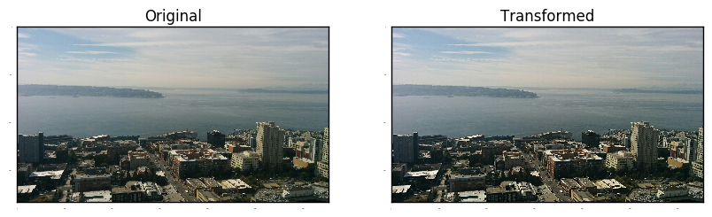

```python
sharpened = sharpen(original_image, 1.3, 0.3)
plot_side_by_side(original_image, sharpened, "image")
```

(Yes, you can also use this same function to just blur your image if you want to)

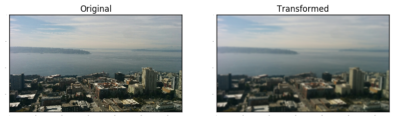

```python
blurred = sharpen(original_image, 0, -1.0)
plot_side_by_side(original_image, blurred, "image")
```

## Adjusting channels by linear interpolation

The range [0, 1] is broken into the range of buckets and linearly interpolate between them. It's like the same as a curve adjustment in any photo editing software.

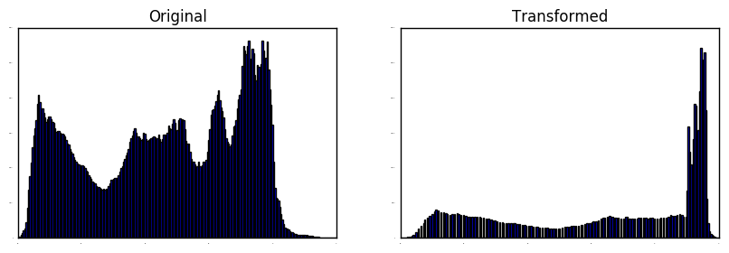

```python
plot_side_by_side(r, r2, "hist")
plt.show()
```

Let's make a function that takes a single channel of an image and adjust it according to a list of values.

```python
def channel_adjust(channel, values):
    # flatten
    orig_size = channel.shape
    flat_channel = channel.flatten()
    adjusted = np.interp(
        flat_channel,
        np.linspace(0, 1, len(values)),
        values)

    # put back into image form
    return adjusted.reshape(orig_size)
```

One more set of helper functions.

```python
# skimage loads images in RGB format
def split_image_into_channels(image):
    red_channel = image[:, :, 0]
    green_channel = image[:, :, 1]
    blue_channel = image[:, :, 2]
    return red_channel, green_channel, blue_channel
```

```python
# and we'll have to undo it
def merge_channels(red_channel, green_channel, blue_channel):
    return np.stack([red_channel, green_channel, blue_channel], axis=2)
```

So you believe this works:

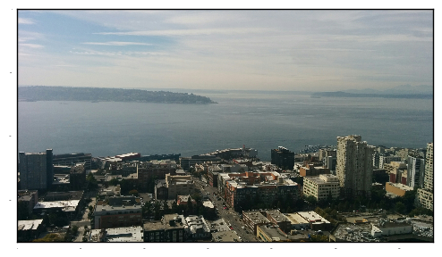

```python
r, g, b = split_image_into_channels(original_image)
im = merge_channels(r, g, b)
plt.imshow(im)
plt.show()
```

The (now-defunct) Gotham filter from Instagram is like this:

1. A mid-tone contrast boost
2. Make the blacks a little bluer
3. A small sharpening
4. A boost in blue channel for lower mid-tones
5. A decrease in blue channel for upper mid-tones

Mid-tone contrast boost.

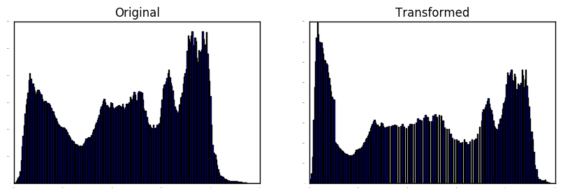

```python
r_boost_lower = channel_adjust(r, [0, 0.05, 0.1, 0.2, 0.3, 0.5, 0.7, 0.8, 0.9, 0.95, 1.0])
plot_side_by_side(r, r_boost_lower, "hist")
```

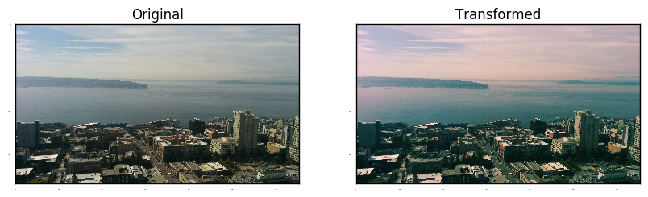

```python
r_boost_img = merge_channels(r_boost_lower, g, b)
plot_side_by_side(original_image, r_boost_img, "image")
```

Make the blacks a little bluer.

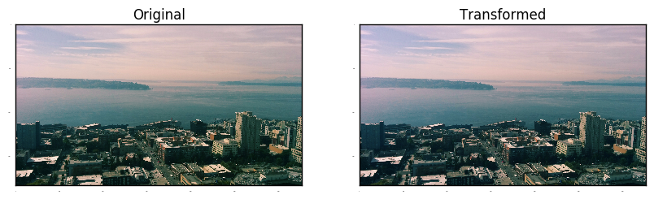

```python
bluer_blacks = merge_channels(r_boost_lower, g, np.clip(b + 0.03, 0, 1.0))
plot_side_by_side(r_boost_img, bluer_blacks, "image")
```

Sharpen the image.

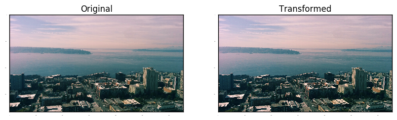

```python
sharper = sharpen(bluer_blacks, 1.3, 0.3)
plot_side_by_side(bluer_blacks, sharper, "image")
```

A boost in blue channel for lower mid-tones and decrease in blue channel for upper mid-tones.

```python
r, g, b = split_image_into_channels(sharper)
b_adjusted = channel_adjust(b, [0, 0.047, 0.118, 0.251, 0.318, 0.392, 0.42, 0.439, 0.475, 0.561, 0.58, 0.627, 0.671, 0.733, 0.847, 0.925, 1])
```

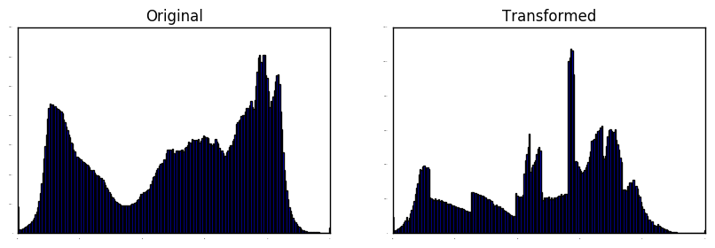

```python
plot_side_by_side(b, b_adjusted, "hist")
```

And voila!

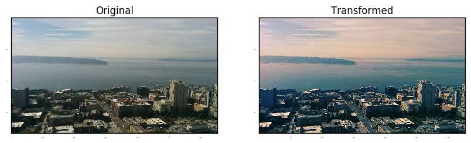

```python
gotham = merge_channels(r, g, b_adjusted)
plot_side_by_side(original_image, gotham, "image")
```

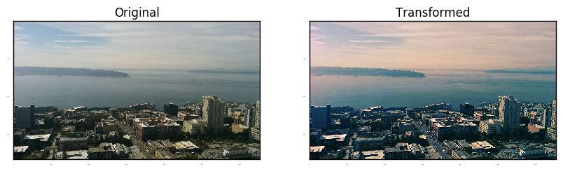

```python
# all told, 15 lines
def channel_adjust(channel, values):
    orig_size = channel.shape
    flat_channel = channel.flatten()
    adjusted = np.interp(flat_channel, np.linspace(0, 1, len(values)), values)
    return adjusted.reshape(orig_size)
r = original_image[:, :, 0]
b = original_image[:, :, 2]
r_boost_lower = channel_adjust(r, [0, 0.05, 0.1, 0.2, 0.3, 0.5, 0.7, 0.8, 0.9, 0.95, 1.0])
b_more = np.clip(b + 0.03, 0, 1.0)
merged = np.stack([r_boost_lower, original_image[:, :, 1], b_more], axis=2)
blurred = skimage.filters.gaussian(merged, sigma=10, multichannel=True)
final = np.clip(merged * 1.3 - blurred * 0.3, 0, 1.0)
b = final[:, :, 2]
b_adjusted = channel_adjust(b, [0, 0.047, 0.118, 0.251, 0.318, 0.392, 0.42, 0.439, 0.475, 0.561, 0.58, 0.627, 0.671, 0.733, 0.847, 0.925, 1])
final[:, :, 2] = b_adjusted
plot_side_by_side(original_image, final, "image")
```